# l9_es

Seminario de Investigación

Semana 9: Regresión

Sergi Martínez

smsoler@clio.uc3m.es | Horario de tutorías: martes 10:00–13:00 (previo correo)

## Hoy

- 9 de noviembre:
  - Preparación
  - Regresión: lógica y (repaso), estimación
  - Regresión multivariada: buenos-malos controles, estimación, e interpretación
  - Modelos de regresión con interacciones

¿Qué tenéis que entregar?

- 1. Corregir los errores de la primera entrega (si los hay)
- 2. Descripción y justificación del caso de estudio, periodo temporal, área geográfica, etc.
- **(3) descripción y justificación del diseño cualitativo**

## Ejemplo: Parkinson [puro quali]

[interactive chart not shown]

## Ejemplo: Ammassari [métodos mixtos corto]

[interactive chart not shown]

## Ejemplo: Amat [métodos mixtos extenso]

[interactive chart not shown]

**Regresión (y control)**

## Regresión bivariada

**Otras propiedades de la regresión**

- El signo de la covarianza, la correlación y la $\hat{\beta}$ de la regresión es el mismo.

```r
d1 <- d %>% drop_na(prob_vox, ideologia)

cov(d1$prob_vox, d1$ideologia)
```

```
[1] 6.637027
```

```r
cor(d1$prob_vox, d1$ideologia)
```

```
[1] 0.6670438
```

```r
lm(d1$prob_vox ~ d1$ideologia)
```

```
Call:
lm(formula = d1$prob_vox ~ d1$ideologia)

Coefficients:
 (Intercept)  d1$ideologia
      -1.571         0.987
```

## Correlación vs. Regresión

Recordemos, *¿qué nos dice la correlación?*

- Cómo de lineal es la relación.

¿*Qué nos dice la beta de la regresión*?

- **La pendiente de la línea de regresión**. Cuánto va hacia $\Delta$ (o $\nabla$) Y, según la línea de la regresión, cuando nos movemos una unidad hacia la derecha (+1) en la X.

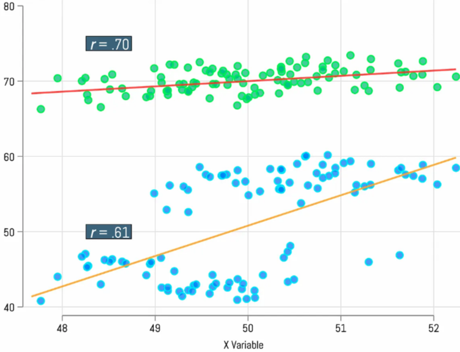